# PML Project

mapologo

22 de febrero de 2015

# Load and process Data

```r
setwd("~/projects/predmachlearn-011/")
pml_training <- read.csv("data/pml-training.csv")
# summary(pml_training)
```

Summary() funtion shows that there are empty values in fields as “min_yaw_belt” and “#DIV/0!” values in fields as “min_yaw_forearm” that make that these fields are taken as factor. So, this values has to be read as NA.

```r
setwd("~/projects/predmachlearn-011/")
pml_training <- read.csv("data/pml-training.csv", na.strings=c("NA","#DIV/0!",""))
# summary(pml_training) # no more incorrect factor fields
```

Some columns had a lot of missing values and the others none. So take only columns without missing values.

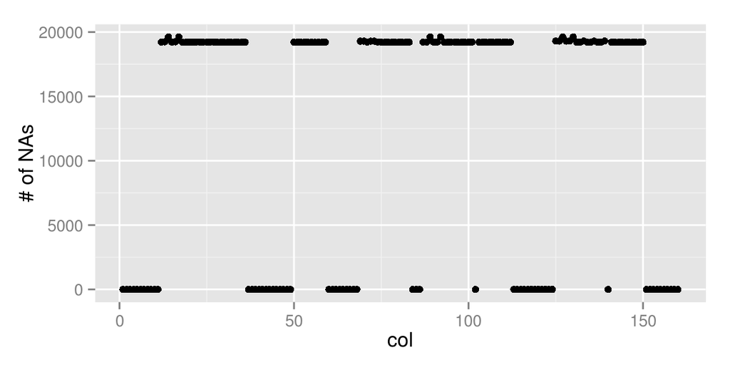

```r
library(ggplot2)
qplot(1:ncol(pml_training), colSums(is.na(pml_training)), xlab = "col", ylab = "# of NAs")
```

```r
predictors <- colnames(pml_training)
predictors <- predictors[colSums(is.na(pml_training)) == 0] # columns without missing values
```

First seven columns are description, time and window data, therefore are not relevant

```r
predictors <- predictors[-(1:7)]
```

With this selection we have gone from 160 to 53 columns. All the remaining predictors are not near zero variance.

```r
library("caret")
# nearZeroVar(pml_training[, predictors], saveMetrics = TRUE)
```

We take our final data set:

```r
pml_training <- pml_training[, predictors]
```

Load the testing data to use our final model for blind prediction:

```r
setwd("~/projects/predmachlearn-011/")
pml_testing <- read.csv("data/pml-testing.csv", na.strings=c("NA","#DIV/0!",""))
pml_testing <- pml_testing[, predictors[1:52]]
```

# Exploratory Analysis

We want to see how our predictors behave, as we have many variables (52), we separated them in 4 subsets of 13 for “bet”, “dumbbell”, “arm” and “forearm” variables:

```r
beltC <- c(grep("belt", predictors), 53)
dumbC <- c(grep("dumbbell", predictors), 53)
armC <- c(grep("[^(fore)]arm", predictors), 53)
foreC <- c(grep("forearm", predictors), 53)
```

Then we plot them using violen geometry:

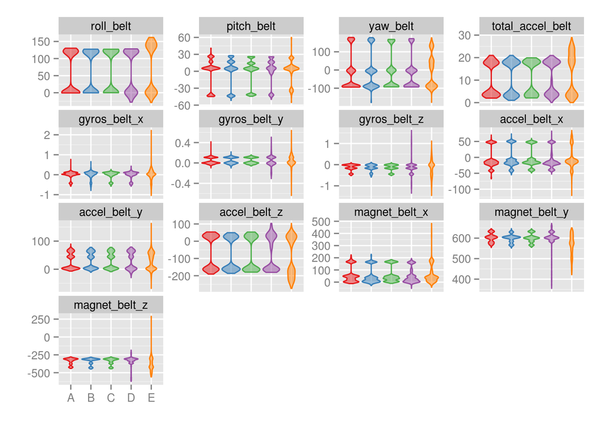

```r
library(reshape2)

groupViolin <- function(groupC){
    groupM <- melt(pml_training[, groupC], id.vars = "classe")
    ggplot(groupM, aes(x=classe, y=value)) +
        geom_violin(aes(color=classe, fill=classe), alpha=1/2) +
        facet_wrap(~ variable, scale="free_y") +
        scale_color_brewer(palette="Set1") +
        scale_fill_brewer(palette="Set1") +
        labs(x="", y="") +
        theme(legend.position="none")
}

groupViolin(beltC)
```

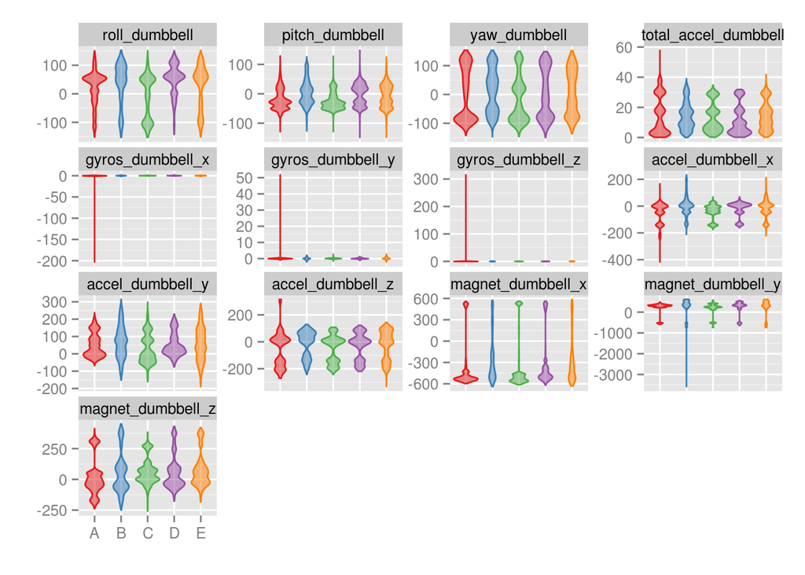

```r
groupViolin(dumbC)
```

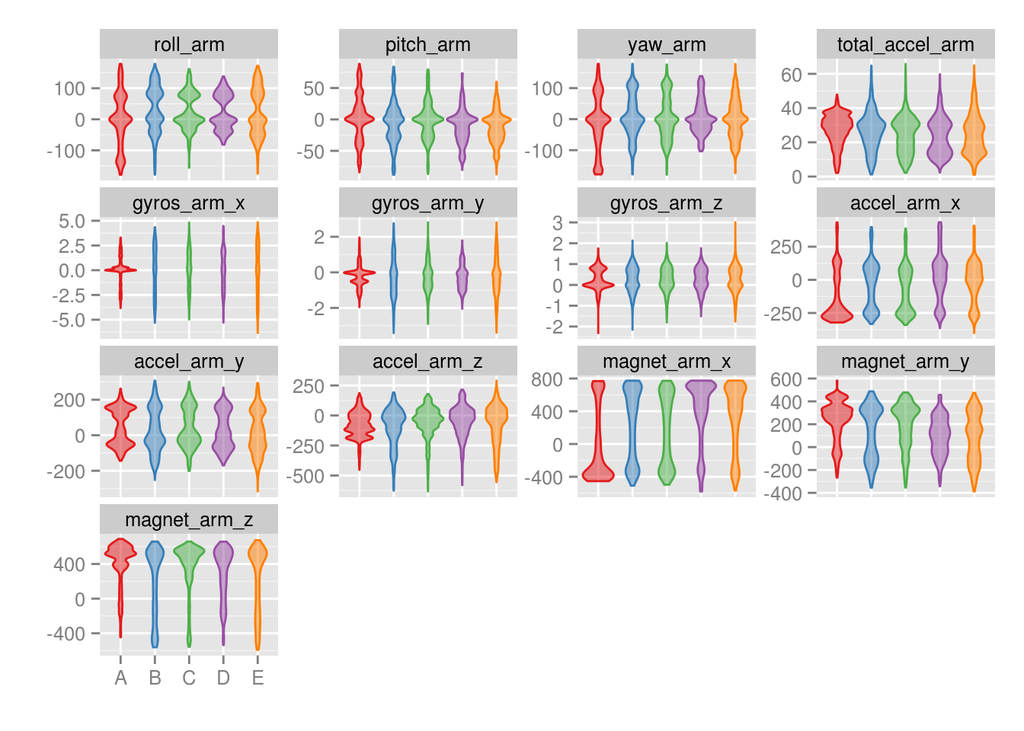

```r
groupViolin(armC)
```

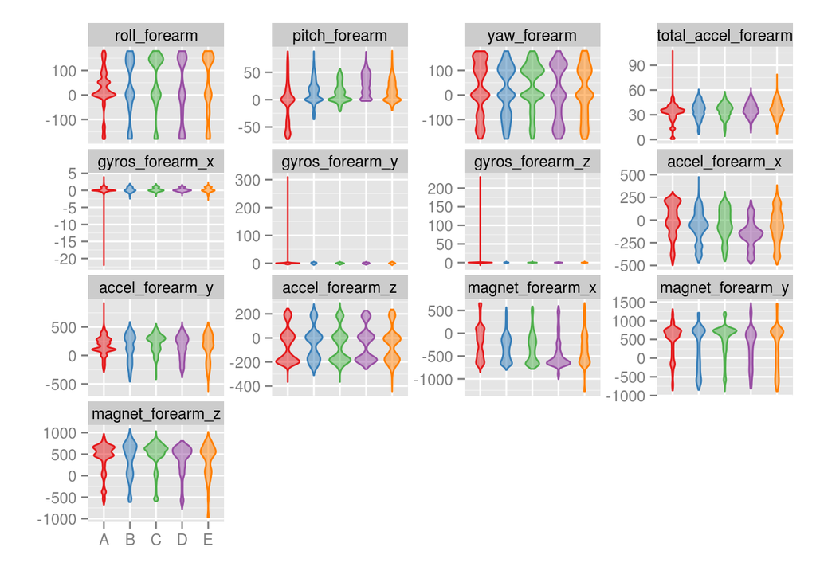

```r
groupViolin(foreC)
```

# Train parameters and data partition

We set our train parameters as 5-fold repeated cross validation across different models:

```r
library(caret)

# Train control across models
trCtrl <- trainControl(method="repeatedcv", number=5, repeats=1,
                       verboseIter=FALSE)
```

And split pml_training dataset in 60% training and 40% testing.

```r
## set seed
set.seed(300369)

inTrain <- createDataPartition(y=pml_training$classe, p=0.6, list=FALSE)
training <- pml_training[inTrain, ]
testing <- pml_training[-inTrain, ]
dim(training)
```

```
## [1] 11776    53
```

```r
dim(testing)
```

```
## [1] 7846   53
```

# Preprocessing

To avoid numerical annoyances, calculate centering and scaling over training data, and apply to training and testing subsets.

```r
library("data.table")

preProc <- preProcess(training[1:52])
predppTrain <- predict(preProc, training[1:52])
trainingCS <- data.table(data.frame(classe = training$classe, predppTrain))

predppTest <- predict(preProc, testing[1:52])
testingCS <- data.table(data.frame(classe = testing$classe, predppTest))
```

# Decision tree

We start trying with a simple decision tree model.

```r
system.time(treeFit <- train(classe ~., data=trainingCS, method="rpart", trControl=trCtrl))
```

```
##    user  system elapsed
##  17.781   0.052  17.999
```

```r
treePred <- predict(treeFit, newdata=testingCS)
treeCM <- confusionMatrix(treePred, testingCS$classe)
treeCM
```

```
## Confusion Matrix and Statistics
##
##           Reference
## Prediction    A    B    C    D    E
##          A 2001  629  625  572  193
##          B   46  540   44  239  204
##          C  179  349  699  475  404
##          D    0    0    0    0    0
##          E    6    0    0    0  641
##
## Overall Statistics
##
##                Accuracy : 0.4946
##                  95% CI : (0.4835, 0.5058)
##     No Information Rate : 0.2845
##     P-Value [Acc > NIR] : < 2.2e-16
##
##                   Kappa : 0.3401
##  Mcnemar's Test P-Value : NA
##
## Statistics by Class:
##
##                      Class: A Class: B Class: C Class: D Class: E
## Sensitivity            0.8965  0.35573  0.51096   0.0000  0.44452
## Specificity            0.6404  0.91577  0.78280   1.0000  0.99906
## Pos Pred Value         0.4978  0.50326  0.33191      NaN  0.99073
## Neg Pred Value         0.9396  0.85560  0.88345   0.8361  0.88873
## Prevalence             0.2845  0.19347  0.17436   0.1639  0.18379
## Detection Rate         0.2550  0.06882  0.08909   0.0000  0.08170
## Detection Prevalence   0.5124  0.13676  0.26842   0.0000  0.08246
## Balanced Accuracy      0.7684  0.63575  0.64688   0.5000  0.72179
```

For pedagogical reasons we present a plot given by `rattle` package.

```r
library("rattle")
```

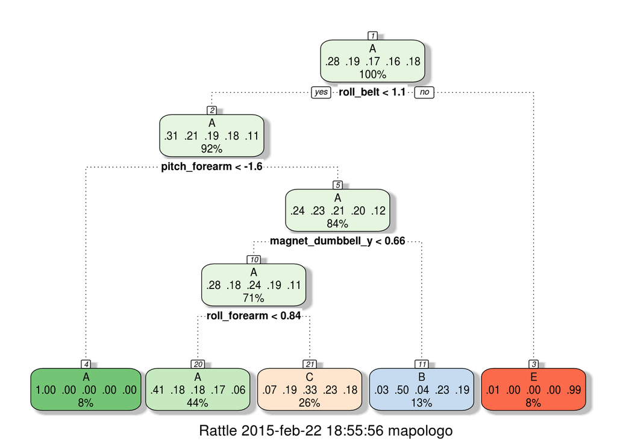

```r
library("rpart.plot")
fancyRpartPlot(treeFit$finalModel)
```

This fancy model only gives 49.46 % of Accuracy.

# Linear Discriminant Analysis

We try also with a fast Linear Discriminant Analysis model.

```r
system.time(ldaFit <- train(classe ~., data=trainingCS, method="lda", trControl=trCtrl))
```

```
##    user  system elapsed
##   2.499   0.092   2.732
```

```r
ldaPred <- predict(ldaFit, newdata=testingCS)
ldaCM <- confusionMatrix(ldaPred, testingCS$classe)
ldaCM
```

```
## Confusion Matrix and Statistics
##
##           Reference
## Prediction    A    B    C    D    E
##          A 1800  239  140   78   56
##          B   48  995  160   56  249
##          C  195  161  895  151  129
##          D  181   68  144  931  143
##          E    8   55   29   70  865
##
## Overall Statistics
##
##                Accuracy : 0.6992
##                  95% CI : (0.6889, 0.7093)
##     No Information Rate : 0.2845
##     P-Value [Acc > NIR] : < 2.2e-16
##
##                   Kappa : 0.6194
##  Mcnemar's Test P-Value : < 2.2e-16
##
## Statistics by Class:
##
##                      Class: A Class: B Class: C Class: D Class: E
## Sensitivity            0.8065   0.6555   0.6542   0.7240   0.5999
## Specificity            0.9086   0.9189   0.9018   0.9183   0.9747
## Pos Pred Value         0.7782   0.6598   0.5846   0.6346   0.8423
## Neg Pred Value         0.9219   0.9175   0.9251   0.9443   0.9154
## Prevalence             0.2845   0.1935   0.1744   0.1639   0.1838
## Detection Rate         0.2294   0.1268   0.1141   0.1187   0.1102
## Detection Prevalence   0.2948   0.1922   0.1951   0.1870   0.1309
## Balanced Accuracy      0.8575   0.7872   0.7780   0.8211   0.7873
```

This model only gives 69.92 % of Accuracy.

# Random Forest

```r
system.time(rfFit <- train(classe ~., data=trainingCS, method="rf", trControl=trCtrl))
```

```
##    user  system elapsed
## 735.485   6.127 746.158
```

```r
rfPred <- predict(rfFit, newdata=testingCS)
rfCM <- confusionMatrix(rfPred, testingCS$classe)
rfCM
```

```
## Confusion Matrix and Statistics
##
##           Reference
## Prediction    A    B    C    D    E
##          A 2225   12    0    0    0
##          B    6 1501   14    4    0
##          C    1    5 1347   12    1
##          D    0    0    7 1266    7
##          E    0    0    0    4 1434
##
## Overall Statistics
##
##                Accuracy : 0.9907
##                  95% CI : (0.9883, 0.9927)
##     No Information Rate : 0.2845
##     P-Value [Acc > NIR] : < 2.2e-16
##
##                   Kappa : 0.9882
##  Mcnemar's Test P-Value : NA
##
## Statistics by Class:
##
##                      Class: A Class: B Class: C Class: D Class: E
## Sensitivity            0.9969   0.9888   0.9846   0.9844   0.9945
## Specificity            0.9979   0.9962   0.9971   0.9979   0.9994
## Pos Pred Value         0.9946   0.9843   0.9861   0.9891   0.9972
## Neg Pred Value         0.9988   0.9973   0.9968   0.9970   0.9988
## Prevalence             0.2845   0.1935   0.1744   0.1639   0.1838
## Detection Rate         0.2836   0.1913   0.1717   0.1614   0.1828
## Detection Prevalence   0.2851   0.1944   0.1741   0.1631   0.1833
## Balanced Accuracy      0.9974   0.9925   0.9909   0.9912   0.9969
```

```r
pml_testingCS <- predict(preProc, pml_testing)
treePredTesting <- predict(treeFit, newdata=pml_testing)
treePredTesting
```

```
##  [1] E A A E E B E B A E A A B A E E E B E E
## Levels: A B C D E
```

```r
ldaPredTesting <- predict(ldaFit, newdata=pml_testing)
ldaPredTesting
```

```
##  [1] A A C C A C C C A A C C E A E A A E A A
## Levels: A B C D E
```

```r
rfPredTesting <- predict(rfFit, newdata=pml_testing)
rfPredTesting
```

```
##  [1] E A A A A E E A A E A A B A E A E B E A
## Levels: A B C D E
```